# Homework #4: Computational Questions

All computations should be done in this notebook using the R kernel. Working in small groups is allowed, but it is important that you make an effort to master the material and hand in your own work.

#### You will be required to submit this notebook, fully compiled with your solutions, as an Jupyter Notebook and as an HTML file to Canvas by 11:59pm on Thursday, February 27.

#### Read and sign the Honor Code Pledge below:

**Honor Code Pledge: *On my honor, as a University of Colorado Boulder student, I have neither given nor received unauthorized assistance on this work.***

Frederick Thayer

## Problem 1

Let $X$ be the leading digit of a randomly selected number from a large accounting ledger. So, for example, if we randomly draw the number $\$20,695$, then $X = 2$. There is empirical evidence that suggests that "naturally occurring" numbers from large data sets follow a distribution defined by:

\begin{align*} f(x) = \log_{10}\bigg(\frac{x+1}{x}\bigg), \,\,\,\, x = 1,2,...,9. \end{align*}

People who make up numbers to commit accounting fraud tend to give $X$ a (discrete) uniform distribution, i.e. following a distribution given by:

\begin{align*} p(x)=P(X = x) = 1/9 \textrm{ for $x \in \{1,...,9\}$.} \end{align*}

In this problem you will decide whether the taxable incomes for individuals in 1978, contained in the dataset ${\tt tax-SP19-R.csv}$, is fraudulent

#### (a) Load the data from either ${\tt tax-SP19-R.csv}$ or ${\tt tax-SP19-TAB.txt}$.

```r
dat = read.csv("/Users/frederickthayer/documents/nlp/statgit/taxes_1978.csv", header = TRUE)
```

#### (b) Put the data from the data frame in the column titled ${\tt taxIncomes}$ into a vector and then extract the leading digits, use the ${\tt substr()}$ command, [see this link for details](http://rfunction.com/archives/1692).

```r
datvec <- c(dat[,1])
leadvec <- substr(datvec,1,1)
```

#### (c) Create a *density histogram* of the leading digits. (NOTE: The original data was missing some incomes and listed those as ${\tt 0}$, be sure to first remove any ${\tt 0}$'s from your data!! Do this with logical indexing. Also note that the vector of leading digits should be of the class "numeric" (i.e. see the ${\tt class()}$ command) so you may also need the ${\tt as.numeric()}$ command.)

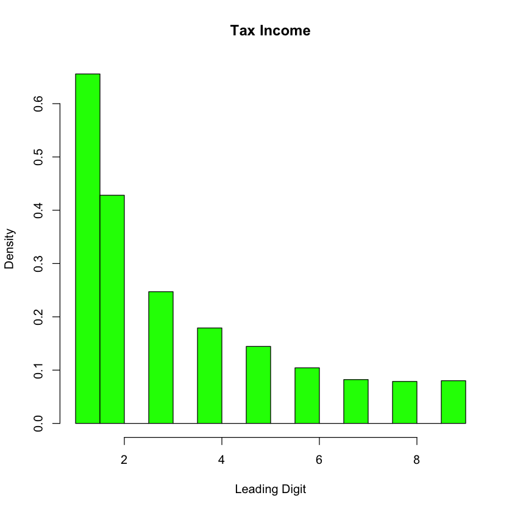

```r
leadvec2 <- as.numeric(leadvec[leadvec != 0])
hist(leadvec2, col="green", border="black", prob = TRUE, xlab = "Leading Digit", main = "Tax Income")
```

#### (d) Re-plot the histogram from part (c) but this time overlay plots of the curves $f(x)$ and $p(x)$ given above in the problem description. Use ${\tt abline()}$ to plot $p(x)$ and use [${\tt curve()}$](https://thomasleeper.com/Rcourse/Tutorials/curve.html) to plot $f(x)$.

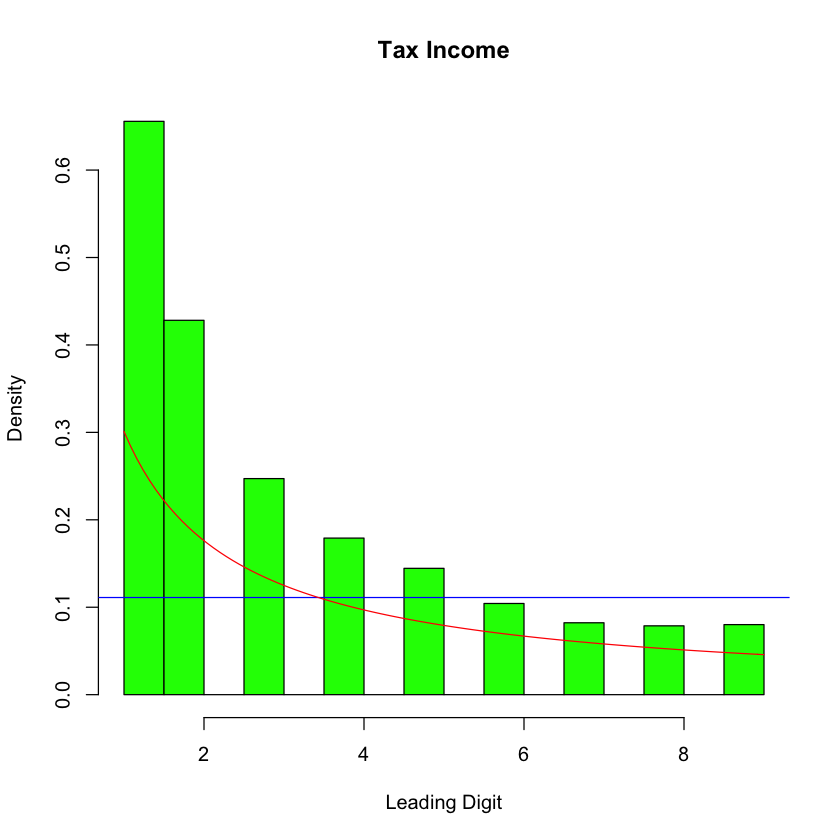

```r
hist(leadvec2, col="green", border="black", prob = TRUE, xlab = "Leading Digit", main = "Tax Income")
abline(h=1/9, col="blue")
curve(log10((1+x)/x), 1, 9, col="red", add=TRUE)
```

#### (e) Comparing the shape of you histogram and the distribution curves, does it appear that the 1978 tax income data is fraudulent? Why or why not.

From this analysis the data does not appear to be fradulently created. While some variance is expected at low sample size, the data set comprises 150K values and clearly follows the red f(x) function representing naturally occuring numbers in large data sets. If it was fradulent, it would be much more likely that the data would vary randomly about the blue Density = 0.111 line.